# Vizualization on the Happines Dataset including Tabacco, Alcohole and Internet consumption

Conor Fallon; Tassilo Henninger

22 6 2022

## Opening Questions

### What influences happiness?

### Happiness over time?

## Datasets and pre-processing

Our base dataset is the [World Happiness Report](https://www.kaggle.com/datasets/mathurinache/world-happiness-report) ranging from 2015 to 2022. The World Happiness Report is a publication of the United Nations Sustainable Development Solutions Network. It contains articles and rankings of national happiness, based on respondent ratings of their own lives, which the report also correlates with various life factors. The dataset contains 12 columns, 1237 rows and can be seen in the table below. As our goal is to analyse the factors of happiness, the following six columns are most important for us: GDP, Family, Health, Freedom, Corruption and Generosity.

| Country | Region | Happiness.Rank | Happiness.Score | Standard.Error | Economy..GDP.per.Capita. | Family | Health..Life.Expectancy. | Freedom | Trust..Government.Corruption. | Generosity | Dystopia.Residual |
| --- | --- | --- | --- | --- | --- | --- | --- | --- | --- | --- | --- |
| Switzerland | Western Europe | 1 | 7.587 | 0.03411 | 1.39651 | 1.34951 | 0.94143 | 0.66557 | 0.41978 | 0.29678 | 2.51738 |
| Iceland | Western Europe | 2 | 7.561 | 0.04884 | 1.30232 | 1.40223 | 0.94784 | 0.62877 | 0.14145 | 0.43630 | 2.70201 |
| Denmark | Western Europe | 3 | 7.527 | 0.03328 | 1.32548 | 1.36058 | 0.87464 | 0.64938 | 0.48357 | 0.34139 | 2.49204 |

In addition, we wanted to add futher factors and added the following three datasets:

- [smoking dataset](https://ourworldindata.org/smoking):
- [alcohol dataset](https://www.kaggle.com/datasets/pralabhpoudel/alcohol-consumption-by-country?resource=download)
- [internet dataset](https://data.worldbank.org/indicator/IT.NET.USER.ZS)

By merging the datasets we have now four additional factors:

- Prevalence of current tobacco use (% of adults)
- Population (historical estimates)
- Total alcohol consumption per capita (liters of pure alcohol, projected estimates, 15+ years of age)
- Individuals using the Internet (% of population)

To join all the different datasets we had to do some manual preprocessing which can be seen in the preprocessing step. The main steps where cleaning the data (region, countrycode, NaN) and joining the datasets based on the year and the countrycode.

After joining we noticed, that the three additional data sets do not contain data for the whole timespan 2015-2022.(fig. missing values full data) Therefore, we decided to create two datasets. One for analysing the happiness change over time and one for analysing the influential factors regarding happiness in only one year.

For the first dataset, the over time analysis, we only included the 6 factors from the base happiness dataset and excluded all rows containing missing values.

| Country | Happiness.Rank | Happiness.Score | Economy..GDP.per.Capita. | Family | Health..Life.Expectancy. | Freedom | Trust..Government.Corruption. | Generosity | Year | Region |
| --- | --- | --- | --- | --- | --- | --- | --- | --- | --- | --- |
| Switzerland | 1 | 7.587 | 1.39651 | 1.34951 | 0.94143 | 0.66557 | 0.41978 | 0.29678 | 2015 | Western Europe |
| Iceland | 2 | 7.561 | 1.30232 | 1.40223 | 0.94784 | 0.62877 | 0.14145 | 0.43630 | 2015 | Western Europe |
| Denmark | 3 | 7.527 | 1.32548 | 1.36058 | 0.87464 | 0.64938 | 0.48357 | 0.34139 | 2015 | Western Europe |

For the second dataset, the influential factors analysis, we inspected the missing values of each year and choose the year with the lowes missing values, year 2018 (fig “missing values 2018”). Then we excluded all rows containing missing values again. Figure “missing values 2017” shows e.g. that the smoking and the alcohol dataset did not contain any values for the year 2017.

| Country | Happiness.Rank | Happiness.Score | Economy..GDP.per.Capita. | Family | Health..Life.Expectancy. | Freedom | Trust..Government.Corruption. | Generosity | Year | Region | Country.Code | Code | Total.alcohol.consumption.per.capita..liters.of.pure.alcohol..projected.estimates..15..years.of.age. | Population..historical.estimates. | Prevalence.of.current.tobacco.use….of.adults. | Individuals.using.the.Internet….of.population. |
| --- | --- | --- | --- | --- | --- | --- | --- | --- | --- | --- | --- | --- | --- | --- | --- | --- |
| Finland | 1 | 7.632 | 1.305 | 1.592 | 0.874 | 0.681 | 0.393 | 0.202 | 2018 | Western Europe | FI | FIN | 10.78 | 5522585 | 19.7 | 88.88996 |
| Norway | 2 | 7.594 | 1.456 | 1.582 | 0.861 | 0.686 | 0.340 | 0.286 | 2018 | Western Europe | NO | NOR | 7.41 | 5337960 | 13.0 | 96.49166 |
| Denmark | 3 | 7.555 | 1.351 | 1.590 | 0.868 | 0.683 | 0.408 | 0.284 | 2018 | Western Europe | DK | DNK | 10.26 | 5752131 | 18.6 | 97.31920 |

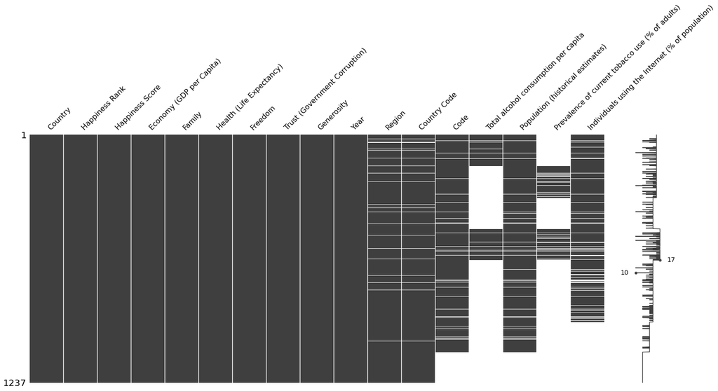

missing values full data

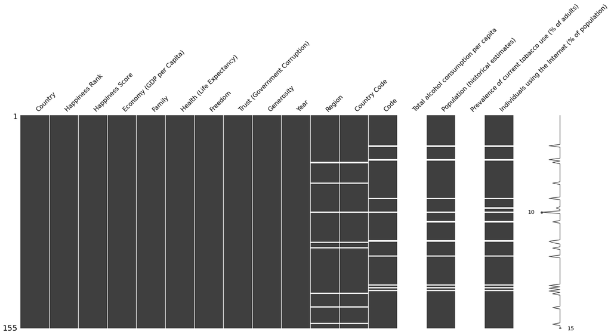

missing values 2017

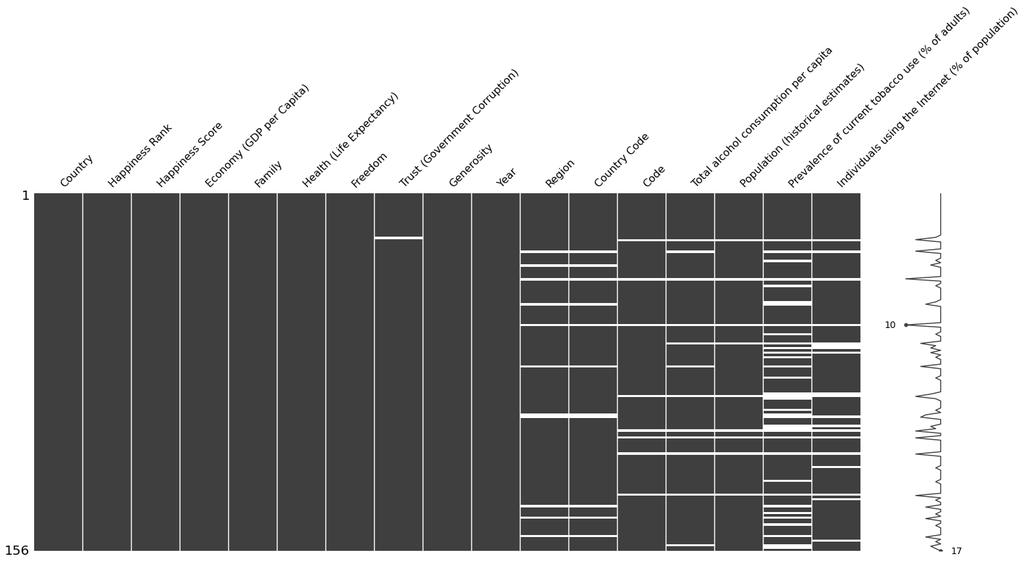

missing values 2018